# Eficiência Veicular

Document Author

2022-09-12

# Como buscar por um carro econômico?

O consumo de combustível é sempre uma preocupação para os motoristas. A cada ano, a indústria automobilística traz atualizações visuais, introduz melhorias na carroceria e mecânica dos automóveis, mas sempre contrabalanceando tais melhorias com o consumo de combustível.

Alguns fatores contribuem para o aumento do consumo de combustíveis, diminuindo a eficiência veicular.

# Base de Dados

A base de dados `mtcars` foi utilizada para avaliar as características responsáveis pela eficiência veicular no que se refere ao consumo de combustível.

Os dados que compõem essa base foram extraídos da revista Motor Trend US de 1974. Abrangem o consumo de combustível e 10 aspectos do design e desempenho de 32 automóveis (modelos de 1973 a 1974).

# Objetivo

A análise objetiva selecionar as características mais relevantes para predizer a eficiencia veicular no que se refere ao consumo de combustível.

# Análise Descritiva

```r
Tabela |>
  knitr::kable()
```

| Siglas | Significado |
| --- | --- |
| mpg | Consumo Milhas/galão |
| cyl | Número de cilindros |
| disp | Deslocamento |
| hp | Potência bruta |
| drat | Relação do eixo traseiro |
| wt | Peso (1000 libras) |
| qsec | Tempo de 1/4 de milha |
| vs | Motor (0\|FormaV; 1\|Reto |
| am | Transmissão (0\|Automática, 1\|Manual) |
| gear | Número de marchas |
| carb | Número de carburadores |

Avaliamos, ainda, a existencia dados faltantes. Nenhum dado faltante foi identificado no bando de dados.

```r
table(map(mtcars, is.na)) |>
  knitr::kable()
```

| mpg | cyl | disp | hp | drat | wt | qsec | vs | am | gear | carb | Freq |
| --- | --- | --- | --- | --- | --- | --- | --- | --- | --- | --- | --- |
| FALSE | FALSE | FALSE | FALSE | FALSE | FALSE | FALSE | FALSE | FALSE | FALSE | FALSE | 32 |

### Após uma análise inicial para conhecer os dados, três aspectos foram

### avaliados em seguida para a condução das análises preditivas:

### i. Avaliação da natureza das variáveis;

## i. Avaliação da natureza das variáveis

As variáveis foram avaliadas e transformadas para que atendessem a natureza de cada uma. Ou seja, as Variáveis categóricas e interiras foram identificadas e transformadas na classe adequada.

```r
mtcars <- mtcars |>
            mutate(vs = as.factor(vs),
                   am = as.factor(am),
                   cyl = as.integer(cyl),
                   gear = as.integer(gear),
                   carb = as.integer(carb))
```

## ii. Colinearidade

Após transformar as varáveis para que atendessem a natureza de cada uma. Foi avaliado a colinearidade entre elas. As variáveis `cyl`|`disp`|`hp`|`wt` se mostraram correlacionadas. Conforme demonstrado abaixo:

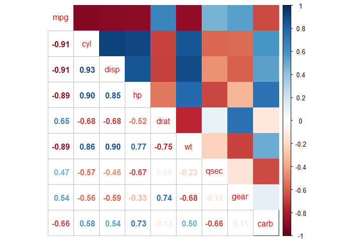

```r
dados_cor <- mtcars  |>
              select (where(is.numeric))

corrplot.mixed(cor(dados_cor, method = "spearman"),lower = "number", upper = 'color')
```

# iii. Linearidade

A inspeção visual das variáveis indicou a necessidade de transformação para atender ao pressuposto de linearidade.

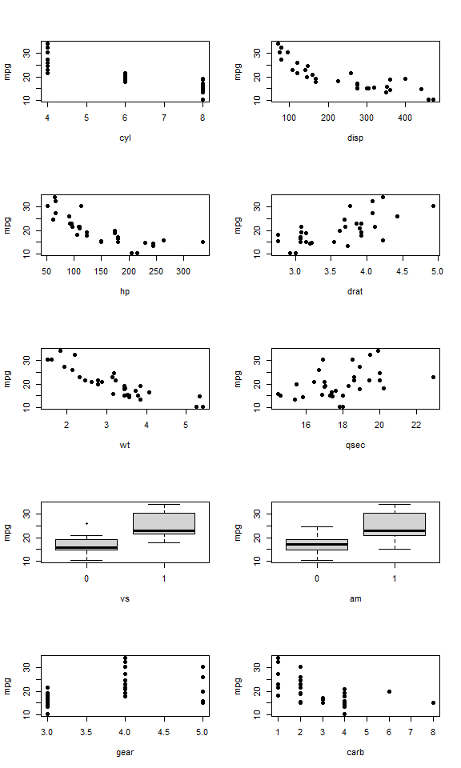

```r
  par(mfrow = c (5,2))
  plot(mpg ~ . , data = mtcars, pch= 16)
```

As variáveis `disp`, `hp`e `wt`, que visualmente não parecem lineares, foram submetidas ao método Box-Cox, para ajudar na indicação do tipo de de transformação que melhor se adequaria para atender a linearidade.

### Vamos descobrir quais características te fazem ficar amigo do frentista mais rápido?